# データの可視化（箱ひげ図）

## x軸の順番を入れ替える

箱ひげ図で複数のクラスタを比較する際は、medianが小さい順に並べたほうが見やすい。 ただ、棒グラフと違って、`fct_reoder()`は順序的な意味合いを持たないfactor型には使えないため、 `transform(x = factor(x ,levels = c("hoge1", "hoge2", "hoge3")))`で並び替えを行う。

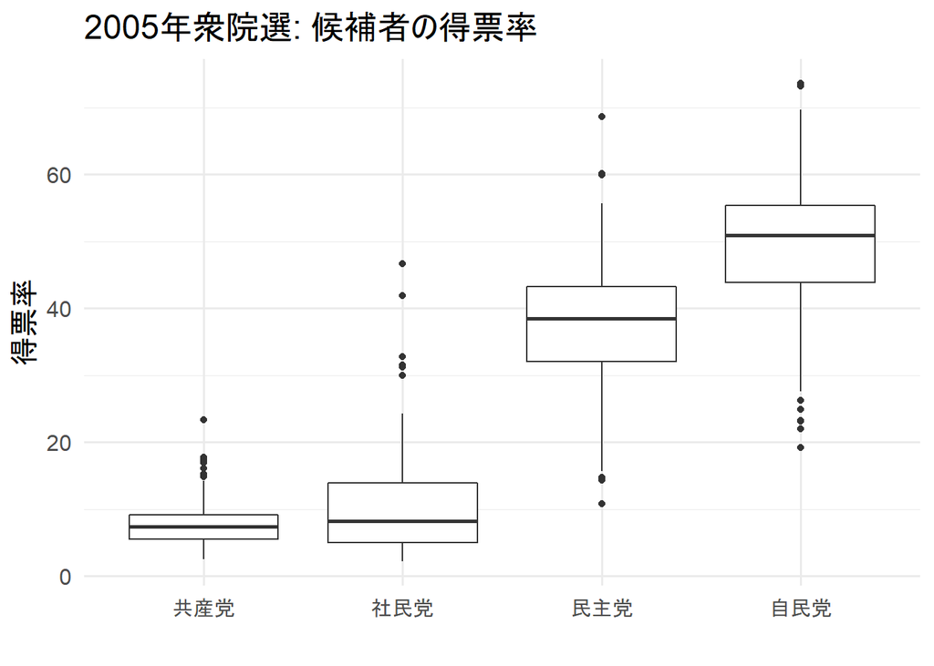

```r
data_2005 %>%
  transform(party_jpn = factor(party_jpn ,levels = c("共産党", "社民党", "民主党", "自民党"))) %>%
  ggplot(aes(x = party_jpn, y = voteshare)) +
  geom_boxplot() +
  labs(x = "", y = "得票率", title = "2005年衆院選: 候補者の得票率")
```

## クラスタごとに色を付ける

クラスタごとに色を付けると、より視認性が向上する（と思う…）。 `scale_fill_manual(values = c("color1", "color2", "color3", "color4"))`で、4色指定すれば自由に色を付けられる。 [Github](https://github.com/FruitGranola/R_Boxplot)のレポジトリの中にカラーリストを入れたので、興味のある人は遊んでみて。

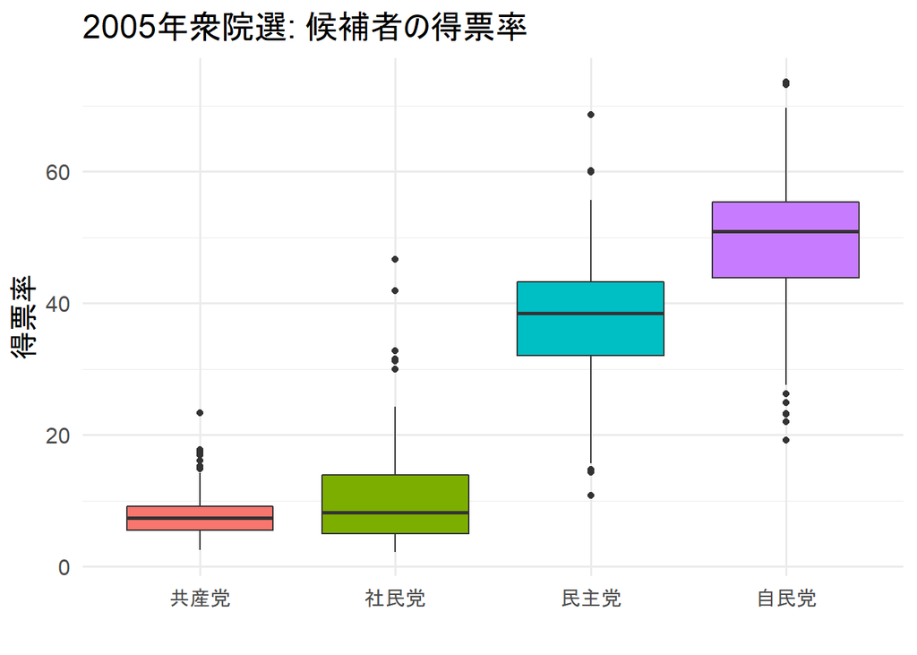

```r
data_2005 %>%
  transform(party_jpn = factor(party_jpn ,levels = c("共産党", "社民党", "民主党", "自民党"))) %>%
  ggplot(aes(x = party_jpn, y = voteshare)) +
  geom_boxplot(aes(fill = party_jpn), show.legend = F) +
  labs(x = "", y = "得票率", title = "2005年衆院選: 候補者の得票率")
```

## 平均値を付け加える

たまにt検定とかすると、「平均値も一緒に見たいなぁ」と思うこともある。そのときは以下のようにすれば、平均値も確認できる。

社民党の平均値とmedianに開きがあるようだ。もしかしたらヒストグラムに歪みがあるかも。

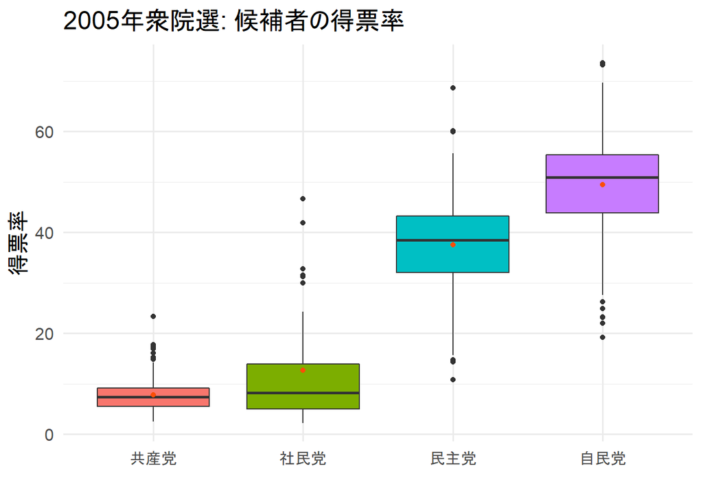

```r
data_2005 %>%
  transform(party_jpn = factor(party_jpn ,levels = c("共産党", "社民党", "民主党", "自民党"))) %>%
  ggplot(aes(x = party_jpn, y = voteshare)) +
  geom_boxplot(aes(fill = party_jpn), show.legend = F) +
  labs(x = "", y = "得票率", title = "2005年衆院選: 候補者の得票率") +
  stat_summary(fun = mean, geom = "point", color = "#FC4E07")
```

## バイオリンプロット

バイオリンプロットを一緒に描くことで、データの分布を確認しながら要約統計量を見ることができる。 社民党の得票率は右方向に裾野が広い分布ため、平均値とmedianが離れていたようだ。 共産党はあまりデータにばらつきが無いように見える。

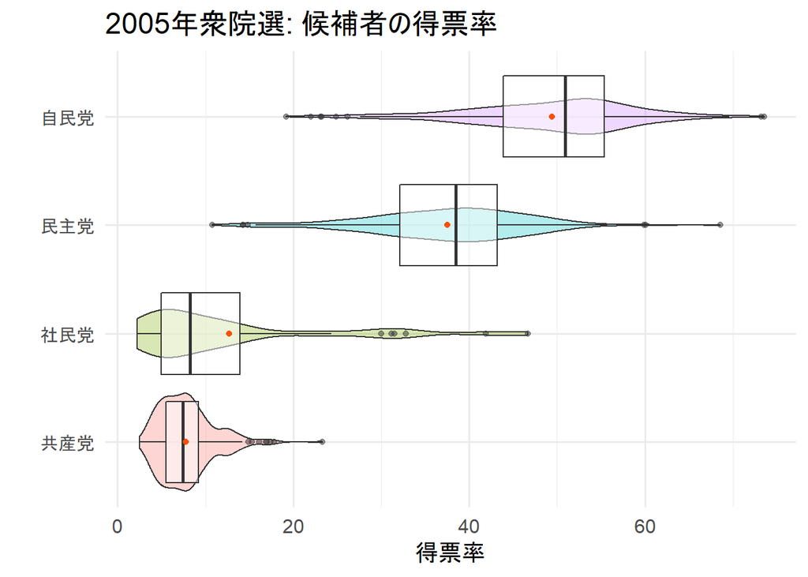

```r
data_2005 %>%
  transform(party_jpn = factor(party_jpn ,levels = c("共産党", "社民党", "民主党", "自民党"))) %>%
  ggplot(aes(x = party_jpn, y = voteshare)) +
  geom_violin(aes(fill = party_jpn), alpha = 0.3, show.legend = F) +
  geom_boxplot(alpha = .5, show.legend = F) +
  labs(x = "", y = "得票率", title = "2005年衆院選: 候補者の得票率") +
  stat_summary(fun = mean, geom = "point", color = "#FC4E07") +
  coord_flip()
```